# Principal Components Analysis

MATH 271.1: Statistical Methods

Jakov Ivan S. Dumbrique[^1]

November 24, 2021

## Step 1: Loading R packages and data sets

Let’s load relevant R packages and data sets we will be using for this lecture.

```r
#install.packages("corrplot")
#install.packages("factoextra")

library(tidyverse)
library("corrplot")
library("factoextra")
```

```r
data(USArrests)
help(USArrests)
```

For each of the fifty states in the United States, the USArrests data set contains the number of arrests per 100,000 residents for each of three crimes: Assault, Murder, and Rape. We also record UrbanPop (the percent of the population in each state living in urban areas).

## Step 2: Exploring the Data

Let’s explore the dataset! Let’s look at the entire dataset.

```r
USArrests
```

|  | Murder | Assault | UrbanPop | Rape |
| --- | --- | --- | --- | --- |
| Alabama | 13.2 | 236 | 58 | 21.2 |
| Alaska | 10.0 | 263 | 48 | 44.5 |
| Arizona | 8.1 | 294 | 80 | 31.0 |
| Arkansas | 8.8 | 190 | 50 | 19.5 |
| California | 9.0 | 276 | 91 | 40.6 |
| Colorado | 7.9 | 204 | 78 | 38.7 |
| Connecticut | 3.3 | 110 | 77 | 11.1 |
| Delaware | 5.9 | 238 | 72 | 15.8 |
| Florida | 15.4 | 335 | 80 | 31.9 |
| Georgia | 17.4 | 211 | 60 | 25.8 |

[output cut: 40 more lines]

```r
USArrests %>%
  summary()
```

```
     Murder          Assault         UrbanPop          Rape
 Min.   : 0.800   Min.   : 45.0   Min.   :32.00   Min.   : 7.30
 1st Qu.: 4.075   1st Qu.:109.0   1st Qu.:54.50   1st Qu.:15.07
 Median : 7.250   Median :159.0   Median :66.00   Median :20.10
 Mean   : 7.788   Mean   :170.8   Mean   :65.54   Mean   :21.23
 3rd Qu.:11.250   3rd Qu.:249.0   3rd Qu.:77.75   3rd Qu.:26.18
 Max.   :17.400   Max.   :337.0   Max.   :91.00   Max.   :46.00
```

```r
USArrests %>%
  apply(2, var)
```

```
    Murder    Assault   UrbanPop       Rape
  18.97047 6945.16571  209.51878   87.72916
```

We see that `Assault` has a much larger variance than the other variables. It would dominate the principal components, so we choose to standardize/scale the variables when we perform PCA.

## Step 3: Performing PCA on the Data

It is mandatory that data should be centered. Centering and scaling can be applied first before calling PCA R functions. The PCA function (prcomp) itself has center and scale parameters. We are going to use prcomp center and scale parameters for preprocessing. We perform PCA after standardizing each variable to have mean zero and standard deviation one. It is important to note that prcomp() uses n-1, not n, in calculating for the variances of the principal components. Tip: always check the documentation of the function you are using! [help(package_name)] We perform PCA on the data set after centering and scaling it.

```r
arrests.pca <- prcomp(USArrests,center = TRUE,scale = TRUE)
arrests.pca
```

```
Standard deviations (1, .., p=4):
[1] 1.5748783 0.9948694 0.5971291 0.4164494

Rotation (n x k) = (4 x 4):
                PC1        PC2        PC3         PC4
Murder   -0.5358995  0.4181809 -0.3412327  0.64922780
Assault  -0.5831836  0.1879856 -0.2681484 -0.74340748
UrbanPop -0.2781909 -0.8728062 -0.3780158  0.13387773
Rape     -0.5434321 -0.1673186  0.8177779  0.08902432
```

```r
arrests.pca %>% names()
```

```
[1] "sdev"     "rotation" "center"   "scale"    "x"
```

The “rotation” matrix above is the matrix of the principal component loading vectors $\phi_k$.

We check the other outputs of arrests.pca:

`arrests.pca$x` gives the four principal components (i.e. the projections of the four features onto each loading vector)

```r
#arrests.pca$center
#arrests.pca$scale
arrests.pca$x
```

```
                       PC1         PC2         PC3          PC4
Alabama        -0.97566045  1.12200121 -0.43980366  0.154696581
Alaska         -1.93053788  1.06242692  2.01950027 -0.434175454
Arizona        -1.74544285 -0.73845954  0.05423025 -0.826264240
Arkansas        0.13999894  1.10854226  0.11342217 -0.180973554
California     -2.49861285 -1.52742672  0.59254100 -0.338559240
Colorado       -1.49934074 -0.97762966  1.08400162  0.001450164
Connecticut     1.34499236 -1.07798362 -0.63679250 -0.117278736
Delaware       -0.04722981 -0.32208890 -0.71141032 -0.873113315
Florida        -2.98275967  0.03883425 -0.57103206 -0.095317042
Georgia        -1.62280742  1.26608838 -0.33901818  1.065974459
Hawaii          0.90348448 -1.55467609  0.05027151  0.893733198
Idaho           1.62331903  0.20885253  0.25719021 -0.494087852
Illinois       -1.36505197 -0.67498834 -0.67068647 -0.120794916
Indiana         0.50038122 -0.15003926  0.22576277  0.420397595
Iowa            2.23099579 -0.10300828  0.16291036  0.017379470
Kansas          0.78887206 -0.26744941  0.02529648  0.204421034
Kentucky        0.74331256  0.94880748 -0.02808429  0.663817237
Louisiana      -1.54909076  0.86230011 -0.77560598  0.450157791
Maine           2.37274014  0.37260865 -0.06502225 -0.327138529
Maryland       -1.74564663  0.42335704 -0.15566968 -0.553450589
Massachusetts   0.48128007 -1.45967706 -0.60337172 -0.177793902
Michigan       -2.08725025 -0.15383500  0.38100046  0.101343128
Minnesota       1.67566951 -0.62590670  0.15153200  0.066640316
Mississippi    -0.98647919  2.36973712 -0.73336290  0.213342049
Missouri       -0.68978426 -0.26070794  0.37365033  0.223554811
Montana         1.17353751  0.53147851  0.24440796  0.122498555
Nebraska        1.25291625 -0.19200440  0.17380930  0.015733156
Nevada         -2.84550542 -0.76780502  1.15168793  0.311354436
New Hampshire   2.35995585 -0.01790055  0.03648498 -0.032804291
New Jersey     -0.17974128 -1.43493745 -0.75677041  0.240936580
New Mexico     -1.96012351  0.14141308  0.18184598 -0.336121113
New York       -1.66566662 -0.81491072 -0.63661186 -0.013348844
North Carolina -1.11208808  2.20561081 -0.85489245 -0.944789648
North Dakota    2.96215223  0.59309738  0.29824930 -0.251434626
Ohio            0.22369436 -0.73477837 -0.03082616  0.469152817
Oklahoma        0.30864928 -0.28496113 -0.01515592  0.010228476
Oregon         -0.05852787 -0.53596999  0.93038718 -0.235390872
Pennsylvania    0.87948680 -0.56536050 -0.39660218  0.355452378
Rhode Island    0.85509072 -1.47698328 -1.35617705 -0.607402746
South Carolina -1.30744986  1.91397297 -0.29751723 -0.130145378
South Dakota    1.96779669  0.81506822  0.38538073 -0.108470512
Tennessee      -0.98969377  0.85160534  0.18619262  0.646302674
Texas          -1.34151838 -0.40833518 -0.48712332  0.636731051
Utah            0.54503180 -1.45671524  0.29077592 -0.081486749
Vermont         2.77325613  1.38819435  0.83280797 -0.143433697
Virginia        0.09536670  0.19772785  0.01159482  0.209246429
Washington      0.21472339 -0.96037394  0.61859067 -0.218628161
West Virginia   2.08739306  1.41052627  0.10372163  0.130583080
Wisconsin       2.05881199 -0.60512507 -0.13746933  0.182253407
Wyoming         0.62310061  0.31778662 -0.23824049 -0.164976866
```

Question: The principal component score vectors have length n = 50, and the principal component loading vectors have length p = 4. Why are there only 4 PC’s?

## Step 4: Determining how many PC’s to retain

Next step is to identify coverage of variance in dataset by individual principal components. We use these Proportions of Variance Explained (PVEs) to determine how many PC’s we need to retain for the dataset. The summary() function and scree plots can be used to explain the variance.

```r
arrests.pca %>%
  summary()
```

```
Importance of components:
                          PC1    PC2     PC3     PC4
Standard deviation     1.5749 0.9949 0.59713 0.41645
Proportion of Variance 0.6201 0.2474 0.08914 0.04336
Cumulative Proportion  0.6201 0.8675 0.95664 1.00000
```

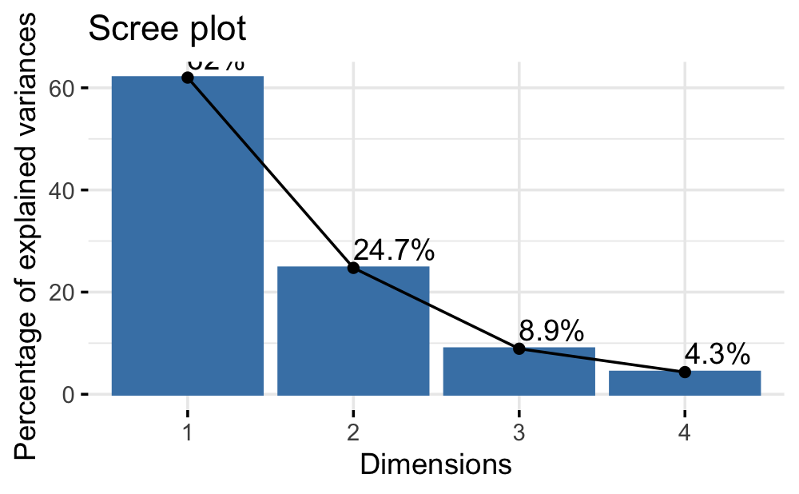

```r
# Scree Plot
arrests.pca %>%
  fviz_eig(addlabels = TRUE)
```

In the USArrests data, the first principal component explains 62.0% of the variance in the data, and the next principal component explains 24.7% of the variance. Together, the first two principal components explain almost 87% of the variance in the data, and the last two principal componentsexplain only 13% of the variance.

## Step 5.1: Analysis through Biplots

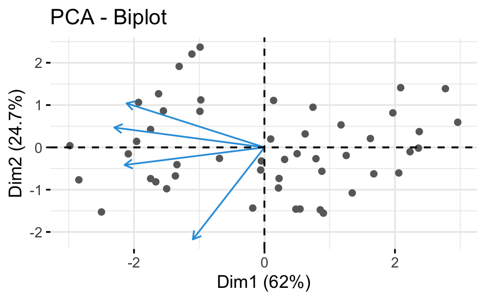

```r
fviz_pca_biplot(arrests.pca, repel = TRUE,
                col.var = "#2E9FDF", # Variables color
                col.ind = "#696969"  # Observations color
                )
```

It seems PCA output concentrated more on negative side. We can actually flip the graph.

```r
pca.out <- arrests.pca
pca.out$rotation <- -pca.out$rotation
pca.out$x <- -pca.out$x
```

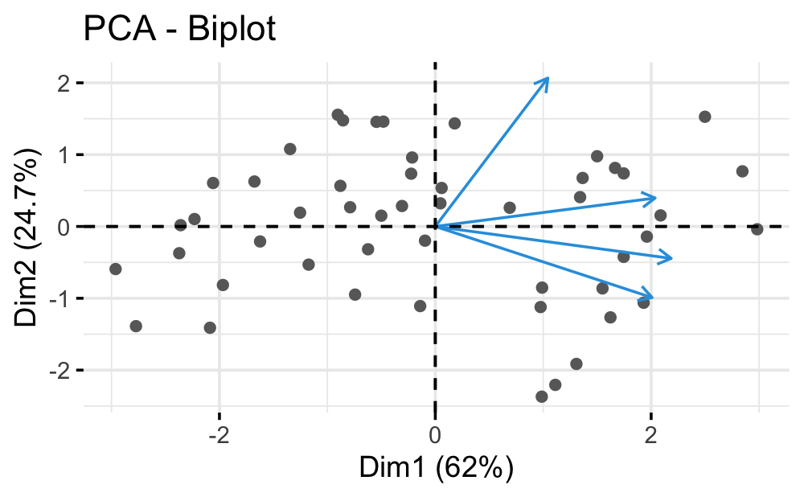

```r
fviz_pca_biplot(pca.out, repel = TRUE,
                col.var = "#2E9FDF", # Variables color
                col.ind = "#696969"  # Observations color
                )
```

## Step 5.2: Analysis through Graphs of variables

### Results

A simple method to extract the results, for variables, from a PCA output is to use the function get_pca_var() [factoextra package]. This function provides a list of matrices containing all the results for the active variables (coordinates, correlation between variables and axes, squared cosine and contributions)

```r
var <- get_pca_var(pca.out)
var
```

```
Principal Component Analysis Results for variables
 ===================================================
  Name       Description
1 "$coord"   "Coordinates for the variables"
2 "$cor"     "Correlations between variables and dimensions"
3 "$cos2"    "Cos2 for the variables"
4 "$contrib" "contributions of the variables"
```

The components of the get_pca_var() can be used in the plot of variables as follow: var$coord: coordinates of variables to create a scatter plot var$cos2: represents the quality of representation for variables on the factor map. It’s calculated as the squared coordinates: var.cos2 = var.coord * var.coord. var$contrib: contains the contributions (in percentage) of the variables to the principal components. The contribution of a variable (var) to a given principal component is (in percentage) : (var.cos2 * 100) / (total cos2 of the component).

Note that, it’s possible to plot variables and to color them according to either i) their quality on the factor map (cos2) or ii) their contribution values to the principal components (contrib). The different components can be accessed as follows:

```r
# Contributions to the principal components
var$contrib
```

```
             Dim.1     Dim.2     Dim.3     Dim.4
Murder   28.718825 17.487524 11.643977 42.149674
Assault  34.010315  3.533859  7.190358 55.265468
UrbanPop  7.739016 76.179065 14.289594  1.792325
Rape     29.531844  2.799553 66.876071  0.792533
```

In this section, we describe how to visualize variables and draw conclusions about their correlations. Next, we highlight variables according to either i) their quality of representation on the factor map or ii) their contributions to the principal components.

### Correlation circle

The correlation between a variable and a principal component (PC) is used as the coordinates of the variable on the PC. The representation of variables differs from the plot of the observations: The observations are represented by their projections, but the variables are represented by their correlations (Abdi and Williams 2010).

```r
# Coordinates
var$coord
```

```
             Dim.1      Dim.2      Dim.3       Dim.4
Murder   0.8439764 -0.4160354  0.2037600 -0.27037052
Assault  0.9184432 -0.1870211  0.1601192  0.30959159
UrbanPop 0.4381168  0.8683282  0.2257242 -0.05575330
Rape     0.8558394  0.1664602 -0.4883190 -0.03707412
```

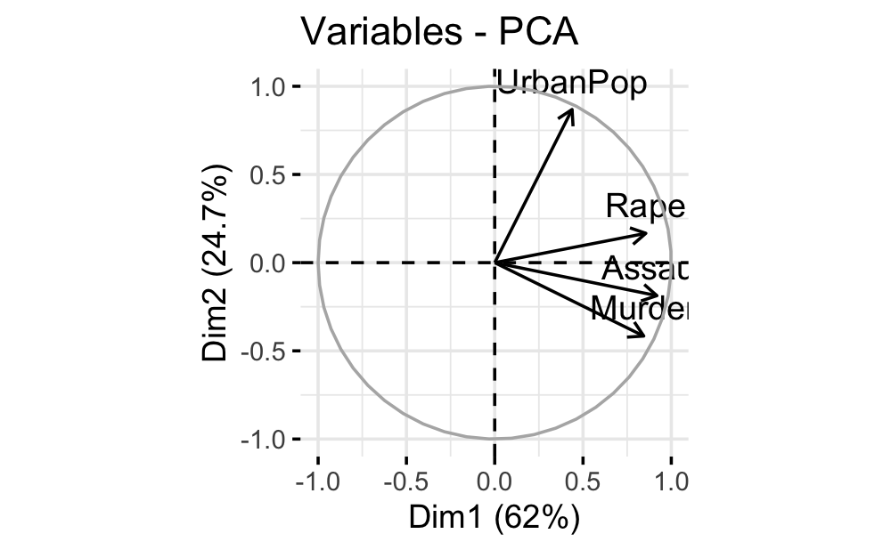

```r
fviz_pca_var(pca.out)
```

The plot above is also known as variable correlation plot. It shows the relationships between all variables. It can be interpreted as follow: 1. Positively correlated variables are grouped together. 2. Negatively correlated variables are positioned on opposite sides of the plot origin (opposed quadrants). 3. The distance between variables and the origin measures the quality of the variables on the factor map. Variables that are away from the origin are well represented on the factor map. We see that the first loading vector places approximately equal weight on Assault, Murder, and Rape, with much less weight on UrbanPop. Hence this component roughly corresponds to a measure of overall rates of serious crimes. The second loading vector places most of its weight on UrbanPop and much less weight on the other three features. Hence, this component roughly corresponds to the level of urbanization of the state. Overall, we see that the crime-related variables (Murder, Assault, and Rape) are located close to each other, and that the UrbanPop variable is far from the other three. This indicates that the crime-related variables are correlated with each other—states with high murder rates tend to have high assault and rape rates—and that the UrbanPop variable is less correlated with the other three.

How do we get these variable coordinates from the PCA results we had earlier?

```r
pca.out$rotation %*% diag(pca.out$sdev)
```

```
              [,1]       [,2]       [,3]        [,4]
Murder   0.8439764 -0.4160354  0.2037600 -0.27037052
Assault  0.9184432 -0.1870211  0.1601192  0.30959159
UrbanPop 0.4381168  0.8683282  0.2257242 -0.05575330
Rape     0.8558394  0.1664602 -0.4883190 -0.03707412
```

### Quality of representation

The quality of representation of the variables on factor map is called cos2 (squared coordinates).

```r
# Cos2: quality on the factor map
var$cos2
```

```
             Dim.1     Dim.2      Dim.3       Dim.4
Murder   0.7122962 0.1730854 0.04151814 0.073100217
Assault  0.8435380 0.0349769 0.02563817 0.095846950
UrbanPop 0.1919463 0.7539938 0.05095143 0.003108430
Rape     0.7324611 0.0277090 0.23845544 0.001374491
```

How do we get the squared coordinates from var$coord?

```r
var$coord^2
```

```
             Dim.1     Dim.2      Dim.3       Dim.4
Murder   0.7122962 0.1730854 0.04151814 0.073100217
Assault  0.8435380 0.0349769 0.02563817 0.095846950
UrbanPop 0.1919463 0.7539938 0.05095143 0.003108430
Rape     0.7324611 0.0277090 0.23845544 0.001374491
```

```r
apply(var$cos2, 1, sum)
```

```
  Murder  Assault UrbanPop     Rape
       1        1        1        1
```

For a given variable, the sum of the cos2 on all the principal components is equal to one. You can visualize the cos2 of variables on all the dimensions using the corrplot package:

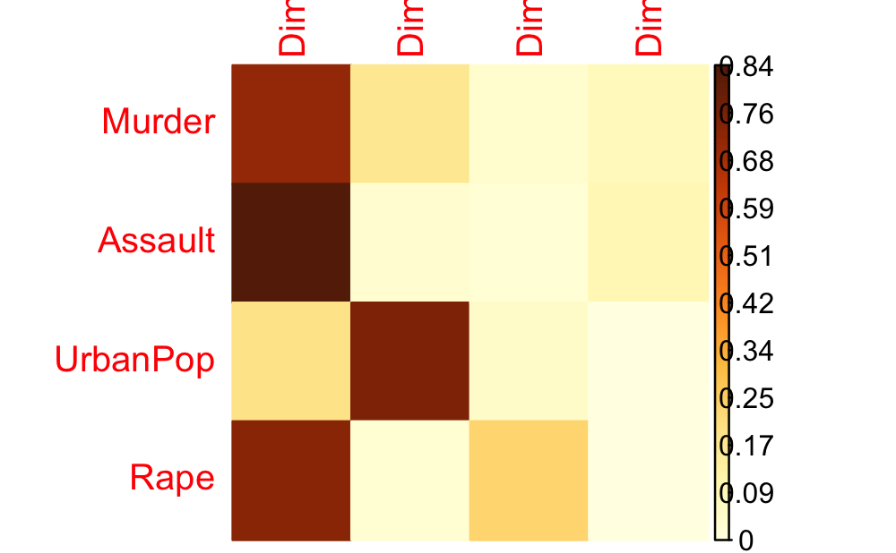

```r
corrplot(var$cos2, method="color", is.corr=FALSE)
```

Note that:

- A high cos2 indicates a good representation of the variable on the principal component loading vector. In this case the variable is positioned close to the circumference of the correlation circle.
- A low cos2 indicates that the variable is not perfectly represented by the PCs. In this case the variable is close to the center of the circle.

### Contributions of variables to PCs

```r
var$contrib
```

```
             Dim.1     Dim.2     Dim.3     Dim.4
Murder   28.718825 17.487524 11.643977 42.149674
Assault  34.010315  3.533859  7.190358 55.265468
UrbanPop  7.739016 76.179065 14.289594  1.792325
Rape     29.531844  2.799553 66.876071  0.792533
```

How do we get the variable contributions?

```r
scale(var$coord^2, center=FALSE, scale=colSums(var$coord^2))*100
```

```
             Dim.1     Dim.2     Dim.3     Dim.4
Murder   28.718825 17.487524 11.643977 42.149674
Assault  34.010315  3.533859  7.190358 55.265468
UrbanPop  7.739016 76.179065 14.289594  1.792325
Rape     29.531844  2.799553 66.876071  0.792533
attr(,"scaled:scale")
    Dim.1     Dim.2     Dim.3     Dim.4
2.4802416 0.9897652 0.3565632 0.1734301
```

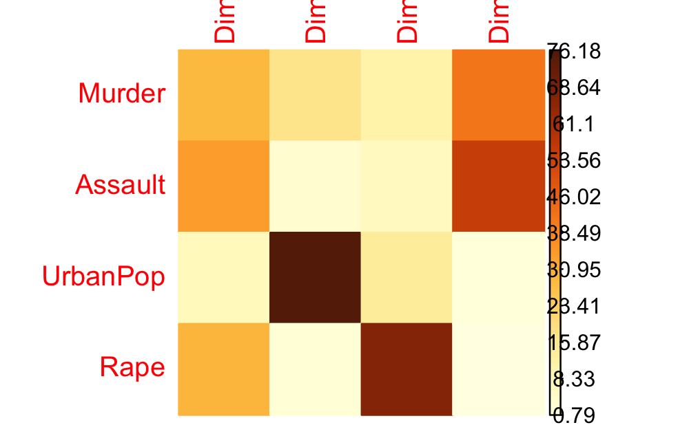

```r
corrplot(var$contrib, method="color", is.corr=FALSE)
```

**The larger the value of the contribution, the more the variable contributes to the component.**

- Variables that are correlated with PC1 loading vector (i.e., Dim.1) and PC2 loading vector (i.e., Dim.2) are the most important in explaining the variability in the data set.
- Variables that do not correlate with any PC loading vector (dimensions) or correlated with the last dimensions are variables with low contribution and might be removed to simplify the overall analysis.

## Step 5.3: Analysis through Graph of observations

### Results

The results, for observations (also called individuals) can be extracted using the function `get_pca_ind()` [*factoextra* package]. Similar to the `get_pca_var()`, the function `get_pca_ind()` provides a list of matrices containing all the results for the individuals (coordinates, correlation between individuals and axes, squared cosines and contributions)

```r
ind <- get_pca_ind(pca.out)
ind
```

```
Principal Component Analysis Results for individuals
 ===================================================
  Name       Description
1 "$coord"   "Coordinates for the individuals"
2 "$cos2"    "Cos2 for the individuals"
3 "$contrib" "contributions of the individuals"
```

```r
# Coordinates of individuals
ind$coord
```

```
                     Dim.1       Dim.2       Dim.3        Dim.4
Alabama         0.97566045 -1.12200121  0.43980366 -0.154696581
Alaska          1.93053788 -1.06242692 -2.01950027  0.434175454
Arizona         1.74544285  0.73845954 -0.05423025  0.826264240
Arkansas       -0.13999894 -1.10854226 -0.11342217  0.180973554
California      2.49861285  1.52742672 -0.59254100  0.338559240
Colorado        1.49934074  0.97762966 -1.08400162 -0.001450164
Connecticut    -1.34499236  1.07798362  0.63679250  0.117278736
Delaware        0.04722981  0.32208890  0.71141032  0.873113315
Florida         2.98275967 -0.03883425  0.57103206  0.095317042
Georgia         1.62280742 -1.26608838  0.33901818 -1.065974459
Hawaii         -0.90348448  1.55467609 -0.05027151 -0.893733198
Idaho          -1.62331903 -0.20885253 -0.25719021  0.494087852
Illinois        1.36505197  0.67498834  0.67068647  0.120794916
Indiana        -0.50038122  0.15003926 -0.22576277 -0.420397595
Iowa           -2.23099579  0.10300828 -0.16291036 -0.017379470
Kansas         -0.78887206  0.26744941 -0.02529648 -0.204421034
Kentucky       -0.74331256 -0.94880748  0.02808429 -0.663817237
Louisiana       1.54909076 -0.86230011  0.77560598 -0.450157791
Maine          -2.37274014 -0.37260865  0.06502225  0.327138529
Maryland        1.74564663 -0.42335704  0.15566968  0.553450589
Massachusetts  -0.48128007  1.45967706  0.60337172  0.177793902
Michigan        2.08725025  0.15383500 -0.38100046 -0.101343128
Minnesota      -1.67566951  0.62590670 -0.15153200 -0.066640316
Mississippi     0.98647919 -2.36973712  0.73336290 -0.213342049
Missouri        0.68978426  0.26070794 -0.37365033 -0.223554811
Montana        -1.17353751 -0.53147851 -0.24440796 -0.122498555
Nebraska       -1.25291625  0.19200440 -0.17380930 -0.015733156
Nevada          2.84550542  0.76780502 -1.15168793 -0.311354436
New Hampshire  -2.35995585  0.01790055 -0.03648498  0.032804291
New Jersey      0.17974128  1.43493745  0.75677041 -0.240936580
New Mexico      1.96012351 -0.14141308 -0.18184598  0.336121113
New York        1.66566662  0.81491072  0.63661186  0.013348844
North Carolina  1.11208808 -2.20561081  0.85489245  0.944789648
North Dakota   -2.96215223 -0.59309738 -0.29824930  0.251434626
Ohio           -0.22369436  0.73477837  0.03082616 -0.469152817
Oklahoma       -0.30864928  0.28496113  0.01515592 -0.010228476
Oregon          0.05852787  0.53596999 -0.93038718  0.235390872
Pennsylvania   -0.87948680  0.56536050  0.39660218 -0.355452378
Rhode Island   -0.85509072  1.47698328  1.35617705  0.607402746
South Carolina  1.30744986 -1.91397297  0.29751723  0.130145378
South Dakota   -1.96779669 -0.81506822 -0.38538073  0.108470512
Tennessee       0.98969377 -0.85160534 -0.18619262 -0.646302674
Texas           1.34151838  0.40833518  0.48712332 -0.636731051
Utah           -0.54503180  1.45671524 -0.29077592  0.081486749
Vermont        -2.77325613 -1.38819435 -0.83280797  0.143433697
Virginia       -0.09536670 -0.19772785 -0.01159482 -0.209246429
Washington     -0.21472339  0.96037394 -0.61859067  0.218628161
West Virginia  -2.08739306 -1.41052627 -0.10372163 -0.130583080
Wisconsin      -2.05881199  0.60512507  0.13746933 -0.182253407
Wyoming        -0.62310061 -0.31778662  0.23824049  0.164976866
```

How do we get these coordinates?

```r
pca.out$x
```

```
                       PC1         PC2         PC3          PC4
Alabama         0.97566045 -1.12200121  0.43980366 -0.154696581
Alaska          1.93053788 -1.06242692 -2.01950027  0.434175454
Arizona         1.74544285  0.73845954 -0.05423025  0.826264240
Arkansas       -0.13999894 -1.10854226 -0.11342217  0.180973554
California      2.49861285  1.52742672 -0.59254100  0.338559240
Colorado        1.49934074  0.97762966 -1.08400162 -0.001450164
Connecticut    -1.34499236  1.07798362  0.63679250  0.117278736
Delaware        0.04722981  0.32208890  0.71141032  0.873113315
Florida         2.98275967 -0.03883425  0.57103206  0.095317042
Georgia         1.62280742 -1.26608838  0.33901818 -1.065974459
Hawaii         -0.90348448  1.55467609 -0.05027151 -0.893733198
Idaho          -1.62331903 -0.20885253 -0.25719021  0.494087852
Illinois        1.36505197  0.67498834  0.67068647  0.120794916
Indiana        -0.50038122  0.15003926 -0.22576277 -0.420397595
Iowa           -2.23099579  0.10300828 -0.16291036 -0.017379470
Kansas         -0.78887206  0.26744941 -0.02529648 -0.204421034
Kentucky       -0.74331256 -0.94880748  0.02808429 -0.663817237
Louisiana       1.54909076 -0.86230011  0.77560598 -0.450157791
Maine          -2.37274014 -0.37260865  0.06502225  0.327138529
Maryland        1.74564663 -0.42335704  0.15566968  0.553450589
Massachusetts  -0.48128007  1.45967706  0.60337172  0.177793902
Michigan        2.08725025  0.15383500 -0.38100046 -0.101343128
Minnesota      -1.67566951  0.62590670 -0.15153200 -0.066640316
Mississippi     0.98647919 -2.36973712  0.73336290 -0.213342049
Missouri        0.68978426  0.26070794 -0.37365033 -0.223554811
Montana        -1.17353751 -0.53147851 -0.24440796 -0.122498555
Nebraska       -1.25291625  0.19200440 -0.17380930 -0.015733156
Nevada          2.84550542  0.76780502 -1.15168793 -0.311354436
New Hampshire  -2.35995585  0.01790055 -0.03648498  0.032804291
New Jersey      0.17974128  1.43493745  0.75677041 -0.240936580
New Mexico      1.96012351 -0.14141308 -0.18184598  0.336121113
New York        1.66566662  0.81491072  0.63661186  0.013348844
North Carolina  1.11208808 -2.20561081  0.85489245  0.944789648
North Dakota   -2.96215223 -0.59309738 -0.29824930  0.251434626
Ohio           -0.22369436  0.73477837  0.03082616 -0.469152817
Oklahoma       -0.30864928  0.28496113  0.01515592 -0.010228476
Oregon          0.05852787  0.53596999 -0.93038718  0.235390872
Pennsylvania   -0.87948680  0.56536050  0.39660218 -0.355452378
Rhode Island   -0.85509072  1.47698328  1.35617705  0.607402746
South Carolina  1.30744986 -1.91397297  0.29751723  0.130145378
South Dakota   -1.96779669 -0.81506822 -0.38538073  0.108470512
Tennessee       0.98969377 -0.85160534 -0.18619262 -0.646302674
Texas           1.34151838  0.40833518  0.48712332 -0.636731051
Utah           -0.54503180  1.45671524 -0.29077592  0.081486749
Vermont        -2.77325613 -1.38819435 -0.83280797  0.143433697
Virginia       -0.09536670 -0.19772785 -0.01159482 -0.209246429
Washington     -0.21472339  0.96037394 -0.61859067  0.218628161
West Virginia  -2.08739306 -1.41052627 -0.10372163 -0.130583080
Wisconsin      -2.05881199  0.60512507  0.13746933 -0.182253407
Wyoming        -0.62310061 -0.31778662  0.23824049  0.164976866
```

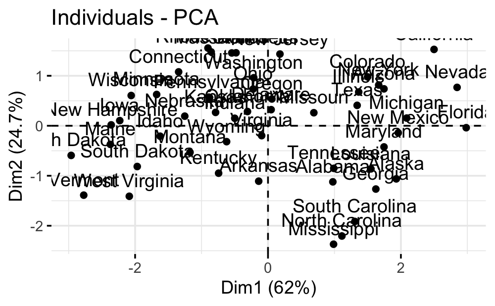

```r
fviz_pca_ind(pca.out)
```

Our discussion of the loading vectors (using the graph of variables) suggests that states with large positive scores on the first component,such as California, Nevada and Florida, have high crime rates, while states like North Dakota, with negative scores on the first component, have low crime rates. California also has a high score on the second component, indicating a high level of urbanization, while the opposite is true for states like Mississippi. States close to zero on both components, such as Indiana and Virginia, have approximately average levels of both crime and urbanization.

Is this supported by our data?

```r
USArrests %>%
  mutate(Crimes = Murder + Assault + Rape) %>%
  arrange(Crimes)
```

|  | Murder | Assault | UrbanPop | Rape | Crimes |
| --- | --- | --- | --- | --- | --- |
| North Dakota | 0.8 | 45 | 44 | 7.3 | 53.1 |
| Vermont | 2.2 | 48 | 32 | 11.2 | 61.4 |
| Wisconsin | 2.6 | 53 | 66 | 10.8 | 66.4 |
| New Hampshire | 2.1 | 57 | 56 | 9.5 | 68.6 |
| Iowa | 2.2 | 56 | 57 | 11.3 | 69.5 |
| Hawaii | 5.3 | 46 | 83 | 20.2 | 71.5 |
| Minnesota | 2.7 | 72 | 66 | 14.9 | 89.6 |
| Maine | 2.1 | 83 | 51 | 7.8 | 92.9 |
| West Virginia | 5.7 | 81 | 39 | 9.3 | 96.0 |
| South Dakota | 3.8 | 86 | 45 | 12.8 | 102.6 |

[output cut: 40 more lines]

```r
USArrests %>%
  arrange(desc(UrbanPop))
```

|  | Murder | Assault | UrbanPop | Rape |
| --- | --- | --- | --- | --- |
| California | 9.0 | 276 | 91 | 40.6 |
| New Jersey | 7.4 | 159 | 89 | 18.8 |
| Rhode Island | 3.4 | 174 | 87 | 8.3 |
| New York | 11.1 | 254 | 86 | 26.1 |
| Massachusetts | 4.4 | 149 | 85 | 16.3 |
| Hawaii | 5.3 | 46 | 83 | 20.2 |
| Illinois | 10.4 | 249 | 83 | 24.0 |
| Nevada | 12.2 | 252 | 81 | 46.0 |
| Arizona | 8.1 | 294 | 80 | 31.0 |
| Florida | 15.4 | 335 | 80 | 31.9 |

[output cut: 40 more lines]

### Squared Cosine of a Component with an Observation (cos2)

The **squared cosine** shows the importance of a principal component for a given observation. The squared cosine indicates the contribution of a component to the squared distance of the observation to the origin. It corresponds to the square of the cosine of the angle from the right triangle made with the origin, the observation, and its projection on the component. Components with a large value of cos2 contribute a relatively large portion to the total distance and therefore these components are important for that observation.

```r
# Quality of individuals
ind$cos2
```

```
                     Dim.1        Dim.2        Dim.3        Dim.4
Alabama        0.392030990 5.184533e-01 0.0796600695 9.855631e-03
Alaska         0.408542467 1.237310e-01 0.4470626440 2.066384e-02
Arizona        0.712223835 1.274849e-01 0.0006875249 1.596038e-01
Arkansas       0.015145647 9.496046e-01 0.0099410946 2.530862e-02
California     0.690465216 2.580267e-01 0.0388311881 1.267690e-02
Colorado       0.513382675 2.182676e-01 0.2683492506 4.802583e-07
Connecticut    0.533580506 3.427557e-01 0.1196068911 4.056943e-03
Delaware       0.001622998 7.548094e-02 0.3682358713 5.546602e-01
Florida        0.963538193 1.633286e-04 0.0353145274 9.839511e-04
Georgia        0.479890482 2.921031e-01 0.0209437358 2.070626e-01
Hawaii         0.202321566 5.990742e-01 0.0006263898 1.979778e-01
Idaho          0.881605007 1.459304e-02 0.0221296805 8.167227e-02
Illinois       0.669460010 1.636887e-01 0.1616089288 5.242321e-03
Indiana        0.500166418 4.496995e-02 0.1018162706 3.530474e-01
Iowa           0.992531591 2.115880e-03 0.0052922975 6.023097e-05
Kansas         0.845225119 9.714994e-02 0.0008691196 5.675582e-02
Kentucky       0.291688374 4.752612e-01 0.0004163927 2.326340e-01
Louisiana      0.607906870 1.883650e-01 0.1523932127 5.133492e-02
Maine          0.957468445 2.361185e-02 0.0007190317 1.820068e-02
Maryland       0.856687080 5.038754e-02 0.0068126744 8.611271e-02
Massachusetts  0.083986303 7.725494e-01 0.1320026372 1.146163e-02
Michigan       0.960514018 5.217530e-03 0.0320041033 2.264349e-03
Minnesota      0.870109037 1.213993e-01 0.0071155038 1.376167e-03
Mississippi    0.135683684 7.829826e-01 0.0749876323 6.346068e-03
Missouri       0.648795750 9.268084e-02 0.1903759837 6.814743e-02
Montana        0.794043831 1.628628e-01 0.0344414327 8.651919e-03
Nebraska       0.958877291 2.251860e-02 0.0184529144 1.511996e-04
Nevada         0.800900045 5.831246e-02 0.1311985745 9.588918e-03
New Hampshire  0.999510473 5.750591e-05 0.0002388954 1.931261e-04
New Jersey     0.011868365 7.564168e-01 0.2103892385 2.132557e-02
New Mexico     0.958573415 4.989277e-03 0.0082502273 2.818708e-02
New York       0.721764161 1.727584e-01 0.1054310669 4.635606e-05
North Carolina 0.160097282 6.297430e-01 0.0946081503 1.155516e-01
North Dakota   0.945686444 3.791267e-02 0.0095871885 6.813693e-03
Ohio           0.061701103 6.657261e-01 0.0011717141 2.714011e-01
Oklahoma       0.538820960 4.592881e-01 0.0012992078 5.917466e-04
Oregon         0.002826986 2.370714e-01 0.7143740849 4.572750e-02
Pennsylvania   0.561820397 2.321613e-01 0.1142481193 9.177021e-02
Rhode Island   0.142785918 4.260025e-01 0.3591648076 7.204677e-02
South Carolina 0.312042985 6.687071e-01 0.0161580367 3.091874e-03
South Dakota   0.824430972 1.414431e-01 0.0316208722 2.505055e-03
Tennessee      0.454078924 3.362067e-01 0.0160714327 1.936429e-01
Texas          0.689760646 6.390558e-02 0.0909458723 1.553879e-01
Utah           0.118337750 8.453352e-01 0.0336818935 2.645170e-03
Vermont        0.744368850 1.865129e-01 0.0671271140 1.991180e-03
Virginia       0.098738949 4.244541e-01 0.0014595649 4.753474e-01
Washington     0.032959393 6.593276e-01 0.2735440166 3.416903e-02
West Virginia  0.683526318 3.121110e-01 0.0016876620 2.674980e-03
Wisconsin      0.910180221 7.862928e-02 0.0040579405 7.132558e-03
Wyoming        0.677323391 1.761777e-01 0.0990172499 4.748165e-02
```

To create a bar plot of the quality of representation (cos2) of individuals on the factor map, you can use the function `fviz_cos2()`

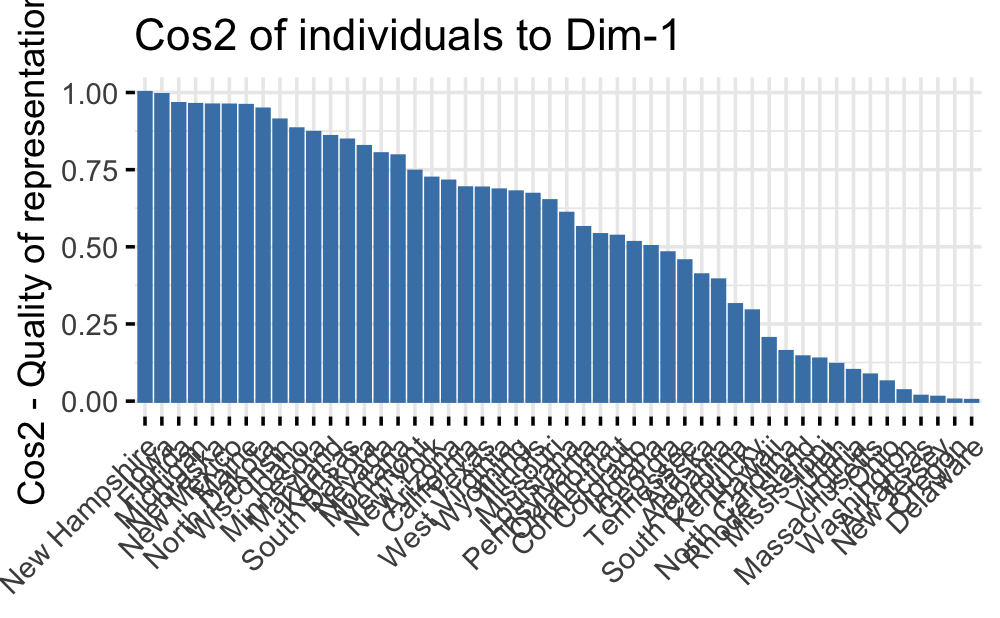

```r
fviz_cos2(pca.out, choice = "ind", axes = 1)
```

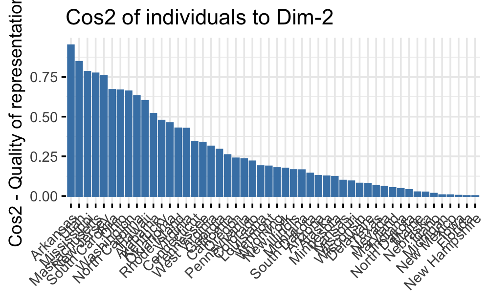

```r
fviz_cos2(pca.out, choice = "ind", axes = 2)
```

### Contribution of an Observation to a Component (contrib)

```r
# Contributions of individuals
ind$contrib
```

```
                     Dim.1        Dim.2        Dim.3        Dim.4
Alabama        0.767597252 2.543809e+00 1.084954e+00 2.759732e-01
Alaska         3.005333458 2.280846e+00 2.287607e+01 2.173883e+00
Arizona        2.456672592 1.101923e+00 1.649593e-02 7.873058e+00
Arkansas       0.015804674 2.483147e+00 7.215881e-02 3.776903e-01
California     5.034240388 4.714315e+00 1.969384e+00 1.321828e+00
Colorado       1.812744908 1.931286e+00 6.591031e+00 2.425157e-05
Connecticut    1.458732469 2.348130e+00 2.274518e+00 1.586149e-01
Delaware       0.001798740 2.096280e-01 2.838794e+00 8.791172e+00
Florida        7.174184420 3.047387e-03 1.829003e+00 1.047723e-01
Georgia        2.123586621 3.239111e+00 6.446730e-01 1.310386e+01
Hawaii         0.658229595 4.884023e+00 1.417547e-02 9.211309e+00
Idaho          2.124925819 8.814087e-02 3.710243e-01 2.815230e+00
Illinois       1.502568867 9.206411e-01 2.523089e+00 1.682685e-01
Indiana        0.201900787 4.548913e-02 2.858895e-01 2.038102e+00
Iowa           4.013594673 2.144085e-02 1.488644e-01 3.483202e-03
Kansas         0.501821384 1.445377e-01 3.589333e-03 4.818998e-01
Kentucky       0.445532054 1.819089e+00 4.424054e-03 5.081625e+00
Louisiana      1.935039081 1.502501e+00 3.374239e+00 2.336873e+00
Maine          4.539796293 2.805458e-01 2.371469e-02 1.234153e+00
Maryland       2.457246257 3.621691e-01 1.359257e-01 3.532346e+00
Massachusetts  0.186780601 4.305379e+00 2.042036e+00 3.645350e-01
Michigan       3.513055856 4.781984e-02 8.142251e-01 1.184388e-01
Minnesota      2.264189355 7.916205e-01 1.287959e-01 5.121293e-02
Mississippi    0.784714837 1.134745e+01 3.016695e+00 5.248781e-01
Missouri       0.383674183 1.373429e-01 7.831126e-01 5.763331e-01
Montana        1.110529158 5.707807e-01 3.350612e-01 1.730484e-01
Nebraska       1.265843739 7.449381e-02 1.694492e-01 2.854547e-03
Nevada         6.529122930 1.191241e+00 7.439832e+00 1.117933e+00
New Hampshire  4.491007385 6.474866e-04 7.466579e-03 1.240986e-02
New Jersey     0.026051436 4.160675e+00 3.212342e+00 6.694390e-01
New Mexico     3.098153195 4.040890e-02 1.854816e-01 1.302858e+00
New York       2.237237951 1.341893e+00 2.273228e+00 2.054910e-03
North Carolina 0.997273744 9.830047e+00 4.099364e+00 1.029380e+01
North Dakota   7.075396141 7.108040e-01 4.989446e-01 7.290473e-01
Ohio           0.040350235 1.090964e+00 5.330062e-03 2.538249e+00
Oklahoma       0.076818628 1.640851e-01 1.288422e-03 1.206500e-03
Oregon         0.002762240 5.804687e-01 4.855354e+00 6.389764e-01
Pennsylvania   0.623727164 6.458754e-01 8.822745e-01 1.457030e+00
Rhode Island   0.589603965 4.408075e+00 1.031636e+01 4.254603e+00
South Carolina 1.378434386 7.402347e+00 4.964983e-01 1.953273e-01
South Dakota   3.122456990 1.342412e+00 8.330547e-01 1.356841e-01
Tennessee      0.789837389 1.465462e+00 1.944547e-01 4.817009e+00
Texas          1.451206676 3.369236e-01 1.330979e+00 4.675387e+00
Utah           0.239540913 4.287925e+00 4.742533e-01 7.657368e-02
Vermont        6.201774575 3.894022e+00 3.890301e+00 2.372509e-01
Virginia       0.007333807 7.900117e-02 7.540878e-04 5.049189e-01
Washington     0.037178745 1.863711e+00 2.146348e+00 5.512108e-01
West Virginia  3.513536592 4.020316e+00 6.034374e-02 1.966434e-01
Wisconsin      3.417978990 7.399257e-01 1.059998e-01 3.830512e-01
Wyoming        0.313077863 2.040653e-01 3.183645e-01 3.138713e-01
```

The function `fviz_contrib()` [factoextra package] can be used to draw a bar plot of individual contributions.

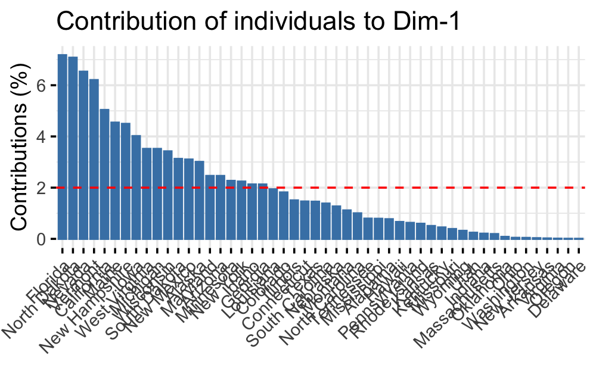

```r
# Contributions of individuals to PC1
fviz_contrib(pca.out, choice = "ind", axes = 1)
```

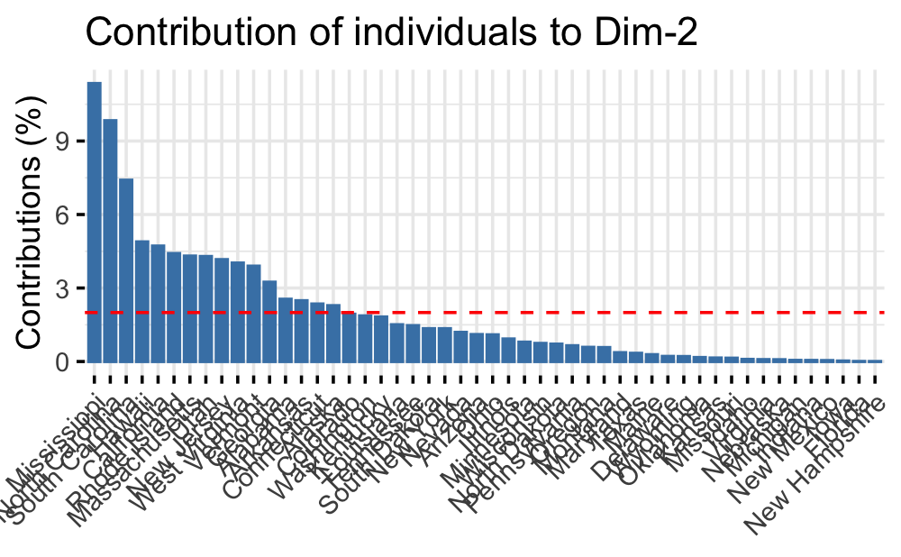

```r
fviz_contrib(pca.out, choice = "ind", axes = 2)
```

The red dashed line on the graph above indicates the expected average contribution. If the contribution of the individuals were uniform, the expected value would be 1/length(individuals) = 1/50 = 2%. For a given component, an individual with a contribution larger than this cutoff could be considered as important in contributing to the component.

```r
# Total contribution on PC1 and PC2
fviz_contrib(pca.out, choice = "ind", axes = 1:2)
```

[output not shown]

Note that, the total contribution of a given individual, on explaining the variations retained by two principal components, say PC1 and PC2, is calculated as contrib = [(C1 * Eig1) + (C2 * Eig2)]/(Eig1 + Eig2), where

- C1 and C2 are the contributions of the individual on PC1 and PC2, respectively
- Eig1 and Eig2 are the eigenvalues of PC1 and PC2, respectively. Recall that eigenvalues measure the amount of variation retained by each PC.

## References

1. https://rpubs.com/njvijay/27823
2. http://www.sthda.com/english/articles/31-principal-component-methods-in-r-practical-guide/112-pca-principal-component-analysis-essentials/
3. http://staff.ustc.edu.cn/~zwp/teach/MVA/abdi-awPCA2010.pdf
4. ISL & ESL
[^1]: Ateneo de Manila University, jdumbrique@ateneo.edu